# Risk Factor Analysis

## Outcome Variable

**Outcome Variable:** co_occurence

## Predictor Variables

**Intervention Variable:** ever_co06

**Adjustment Set:**

unadjusted

## Stratifying Variables

The analysis was stratified on these variable(s):

- studyid
- country

## Data Summary

| studyid | country | ever_co06 | co_occurence | n_cell | n |
| --- | --- | --- | --- | --- | --- |
| ki0047075b-MAL-ED | BANGLADESH | 0 | 0 | 202 | 221 |
| ki0047075b-MAL-ED | BANGLADESH | 0 | 1 | 12 | 221 |
| ki0047075b-MAL-ED | BANGLADESH | 1 | 0 | 5 | 221 |
| ki0047075b-MAL-ED | BANGLADESH | 1 | 1 | 2 | 221 |
| ki0047075b-MAL-ED | BRAZIL | 0 | 0 | 179 | 180 |
| ki0047075b-MAL-ED | BRAZIL | 0 | 1 | 1 | 180 |
| ki0047075b-MAL-ED | BRAZIL | 1 | 0 | 0 | 180 |
| ki0047075b-MAL-ED | BRAZIL | 1 | 1 | 0 | 180 |
| ki0047075b-MAL-ED | INDIA | 0 | 0 | 198 | 228 |
| ki0047075b-MAL-ED | INDIA | 0 | 1 | 13 | 228 |
| ki0047075b-MAL-ED | INDIA | 1 | 0 | 13 | 228 |
| ki0047075b-MAL-ED | INDIA | 1 | 1 | 4 | 228 |
| ki0047075b-MAL-ED | NEPAL | 0 | 0 | 220 | 229 |
| ki0047075b-MAL-ED | NEPAL | 0 | 1 | 3 | 229 |
| ki0047075b-MAL-ED | NEPAL | 1 | 0 | 5 | 229 |
| ki0047075b-MAL-ED | NEPAL | 1 | 1 | 1 | 229 |
| ki0047075b-MAL-ED | PERU | 0 | 0 | 216 | 222 |
| ki0047075b-MAL-ED | PERU | 0 | 1 | 5 | 222 |
| ki0047075b-MAL-ED | PERU | 1 | 0 | 0 | 222 |
| ki0047075b-MAL-ED | PERU | 1 | 1 | 1 | 222 |
| ki0047075b-MAL-ED | SOUTH AFRICA | 0 | 0 | 233 | 241 |
| ki0047075b-MAL-ED | SOUTH AFRICA | 0 | 1 | 4 | 241 |
| ki0047075b-MAL-ED | SOUTH AFRICA | 1 | 0 | 4 | 241 |
| ki0047075b-MAL-ED | SOUTH AFRICA | 1 | 1 | 0 | 241 |
| ki0047075b-MAL-ED | TANZANIA, UNITED REPUBLIC OF | 0 | 0 | 220 | 225 |
| ki0047075b-MAL-ED | TANZANIA, UNITED REPUBLIC OF | 0 | 1 | 1 | 225 |
| ki0047075b-MAL-ED | TANZANIA, UNITED REPUBLIC OF | 1 | 0 | 4 | 225 |
| ki0047075b-MAL-ED | TANZANIA, UNITED REPUBLIC OF | 1 | 1 | 0 | 225 |
| ki1000107-Serrinha-VitA | BRAZIL | 0 | 0 | 10 | 10 |
| ki1000107-Serrinha-VitA | BRAZIL | 0 | 1 | 0 | 10 |

[output cut: 118 more lines]

The following strata were considered:

- studyid: ki0047075b-MAL-ED, country: BANGLADESH
- studyid: ki0047075b-MAL-ED, country: BRAZIL
- studyid: ki0047075b-MAL-ED, country: INDIA
- studyid: ki0047075b-MAL-ED, country: NEPAL
- studyid: ki0047075b-MAL-ED, country: PERU
- studyid: ki0047075b-MAL-ED, country: SOUTH AFRICA
- studyid: ki0047075b-MAL-ED, country: TANZANIA, UNITED REPUBLIC OF
- studyid: ki1000107-Serrinha-VitA, country: BRAZIL
- studyid: ki1000108-CMC-V-BCS-2002, country: INDIA
- studyid: ki1000108-IRC, country: INDIA
- studyid: ki1000109-EE, country: PAKISTAN
- studyid: ki1000109-ResPak, country: PAKISTAN
- studyid: ki1000110-WASH-Bangladesh, country: BANGLADESH
- studyid: ki1000111-WASH-Kenya, country: KENYA
- studyid: ki1000304b-SAS-CompFeed, country: INDIA
- studyid: ki1000304b-SAS-FoodSuppl, country: INDIA
- studyid: ki1017093-NIH-Birth, country: BANGLADESH
- studyid: ki1017093b-PROVIDE, country: BANGLADESH
- studyid: ki1017093c-NIH-Crypto, country: BANGLADESH
- studyid: ki1033518-iLiNS-DYAD-G, country: GHANA
- studyid: ki1066203-TanzaniaChild2, country: TANZANIA, UNITED REPUBLIC OF
- studyid: ki1101329-Keneba, country: GAMBIA
- studyid: ki1112895-Burkina Faso Zn, country: BURKINA FASO
- studyid: ki1113344-GMS-Nepal, country: NEPAL
- studyid: ki1114097-CMIN, country: BANGLADESH
- studyid: ki1114097-CMIN, country: BRAZIL
- studyid: ki1114097-CMIN, country: GUINEA-BISSAU
- studyid: ki1114097-CMIN, country: PERU
- studyid: ki1114097-CONTENT, country: PERU
- studyid: ki1119695-PROBIT, country: BELARUS
- studyid: ki1126311-ZVITAMBO, country: ZIMBABWE
- studyid: ki1135781-COHORTS, country: GUATEMALA
- studyid: ki1135781-COHORTS, country: PHILIPPINES
- studyid: ki1148112-iLiNS-DOSE, country: MALAWI
- studyid: ki1148112-iLiNS-DYAD-M, country: MALAWI
- studyid: ki1148112-LCNI-5, country: MALAWI
- studyid: kiGH5241-JiVitA-4, country: BANGLADESH

### Dropped Strata

Some strata were dropped due to rare outcomes:

- studyid: ki0047075b-MAL-ED, country: BANGLADESH
- studyid: ki0047075b-MAL-ED, country: BRAZIL
- studyid: ki0047075b-MAL-ED, country: INDIA
- studyid: ki0047075b-MAL-ED, country: NEPAL
- studyid: ki0047075b-MAL-ED, country: PERU
- studyid: ki0047075b-MAL-ED, country: SOUTH AFRICA
- studyid: ki0047075b-MAL-ED, country: TANZANIA, UNITED REPUBLIC OF
- studyid: ki1000107-Serrinha-VitA, country: BRAZIL
- studyid: ki1000109-ResPak, country: PAKISTAN
- studyid: ki1000110-WASH-Bangladesh, country: BANGLADESH
- studyid: ki1000111-WASH-Kenya, country: KENYA
- studyid: ki1033518-iLiNS-DYAD-G, country: GHANA
- studyid: ki1066203-TanzaniaChild2, country: TANZANIA, UNITED REPUBLIC OF
- studyid: ki1112895-Burkina Faso Zn, country: BURKINA FASO
- studyid: ki1114097-CMIN, country: BANGLADESH
- studyid: ki1114097-CMIN, country: BRAZIL
- studyid: ki1114097-CMIN, country: GUINEA-BISSAU
- studyid: ki1114097-CMIN, country: PERU
- studyid: ki1114097-CONTENT, country: PERU
- studyid: ki1119695-PROBIT, country: BELARUS
- studyid: ki1135781-COHORTS, country: GUATEMALA
- studyid: ki1148112-iLiNS-DOSE, country: MALAWI
- studyid: ki1148112-iLiNS-DYAD-M, country: MALAWI
- studyid: ki1148112-LCNI-5, country: MALAWI

## Methods Detail

We’re interested in the causal parameters $E[Y_a]$ for all values of $a \in \mathcal{A}$. These parameters represent the mean outcome if, possibly contrary to fact, we intervened to set all units to have $A=a$. Under the randomization and positivity assumptions, these are identified by the statistical parameters $\psi_a=E_W[E_{Y|A,W}(Y|A=a,W)]$. In addition, we’re interested in the mean of $Y$, $E[Y]$ under no intervention (the observed mean). We will estimate these parameters by using SuperLearner to fit the relevant likelihood factors – $E_{Y|A,W}(Y|A=a,W)$ and $p(A=a|W)$, and then updating our likelihood fit using a joint TMLE.

For unadjusted analyses ($W=\{\}$), initial likelihoods were estimated using Lrnr_glm to estimate the simple $E(Y|A)$ and Lrnr_mean to estimate $p(A)$. For adjusted analyses, a small library containing Lrnr_glmnet, Lrnr_xgboost, and Lrnr_mean was used.

Having estimated these parameters, we will then use the delta method to estimate relative risks and attributable risks relative to a prespecified baseline level of $A$.

# Results Detail

## Results Plots

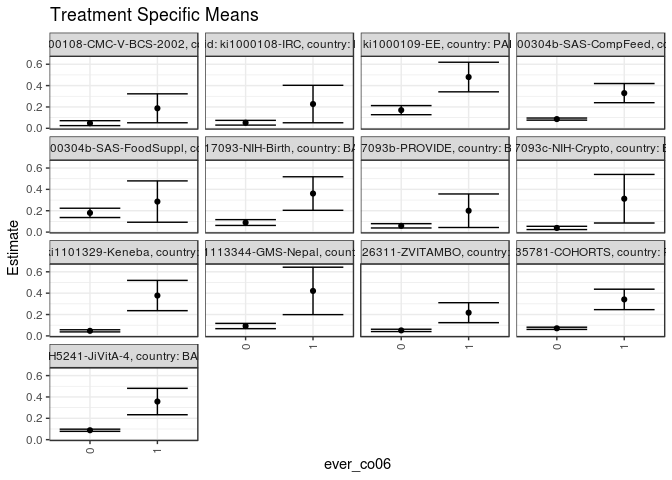

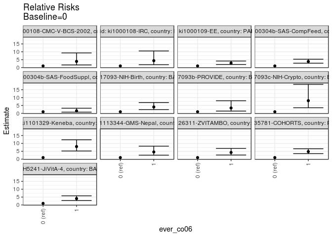

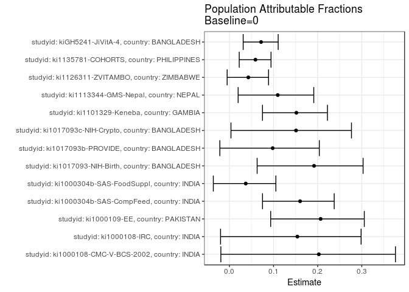

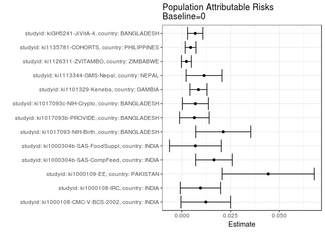

## Results Table

### Parameter: TSM

| studyid | country | intervention_level | baseline_level | estimate | ci_lower | ci_upper |
| --- | --- | --- | --- | --- | --- | --- |
| ki1000108-CMC-V-BCS-2002 | INDIA | 0 | NA | 0.0481928 | 0.0251231 | 0.0712625 |
| ki1000108-CMC-V-BCS-2002 | INDIA | 1 | NA | 0.1875000 | 0.0520800 | 0.3229200 |
| ki1000108-IRC | INDIA | 0 | NA | 0.0522193 | 0.0299116 | 0.0745270 |
| ki1000108-IRC | INDIA | 1 | NA | 0.2272727 | 0.0519411 | 0.4026044 |
| ki1000109-EE | PAKISTAN | 0 | NA | 0.1700000 | 0.1274331 | 0.2125669 |
| ki1000109-EE | PAKISTAN | 1 | NA | 0.4800000 | 0.3413223 | 0.6186777 |
| ki1000304b-SAS-CompFeed | INDIA | 0 | NA | 0.0863248 | 0.0765792 | 0.0960704 |
| ki1000304b-SAS-CompFeed | INDIA | 1 | NA | 0.3294118 | 0.2396589 | 0.4191647 |
| ki1000304b-SAS-FoodSuppl | INDIA | 0 | NA | 0.1800000 | 0.1364580 | 0.2235420 |
| ki1000304b-SAS-FoodSuppl | INDIA | 1 | NA | 0.2857143 | 0.0921978 | 0.4792308 |
| ki1017093-NIH-Birth | BANGLADESH | 0 | NA | 0.0894118 | 0.0622547 | 0.1165689 |
| ki1017093-NIH-Birth | BANGLADESH | 1 | NA | 0.3611111 | 0.2040381 | 0.5181841 |
| ki1017093b-PROVIDE | BANGLADESH | 0 | NA | 0.0588235 | 0.0387165 | 0.0789305 |
| ki1017093b-PROVIDE | BANGLADESH | 1 | NA | 0.2000000 | 0.0430607 | 0.3569393 |
| ki1017093c-NIH-Crypto | BANGLADESH | 0 | NA | 0.0388350 | 0.0235907 | 0.0540792 |
| ki1017093c-NIH-Crypto | BANGLADESH | 1 | NA | 0.3125000 | 0.0852038 | 0.5397962 |
| ki1101329-Keneba | GAMBIA | 0 | NA | 0.0472855 | 0.0372315 | 0.0573394 |
| ki1101329-Keneba | GAMBIA | 1 | NA | 0.3777778 | 0.2360822 | 0.5194734 |
| ki1113344-GMS-Nepal | NEPAL | 0 | NA | 0.0922787 | 0.0676397 | 0.1169177 |
| ki1113344-GMS-Nepal | NEPAL | 1 | NA | 0.4210526 | 0.1988474 | 0.6432578 |
| ki1126311-ZVITAMBO | ZIMBABWE | 0 | NA | 0.0513761 | 0.0405499 | 0.0622024 |
| ki1126311-ZVITAMBO | ZIMBABWE | 1 | NA | 0.2173913 | 0.1238266 | 0.3109560 |
| ki1135781-COHORTS | PHILIPPINES | 0 | NA | 0.0710784 | 0.0608084 | 0.0813484 |
| ki1135781-COHORTS | PHILIPPINES | 1 | NA | 0.3414634 | 0.2458047 | 0.4371221 |
| kiGH5241-JiVitA-4 | BANGLADESH | 0 | NA | 0.0882285 | 0.0781618 | 0.0982952 |
| kiGH5241-JiVitA-4 | BANGLADESH | 1 | NA | 0.3571429 | 0.2335073 | 0.4807785 |

### Parameter: E(Y)

| studyid | country | intervention_level | baseline_level | estimate | ci_lower | ci_upper |
| --- | --- | --- | --- | --- | --- | --- |
| ki1000108-CMC-V-BCS-2002 | INDIA | NA | NA | 0.0604396 | 0.0359254 | 0.0849538 |
| ki1000108-IRC | INDIA | NA | NA | 0.0617284 | 0.0382610 | 0.0851958 |
| ki1000109-EE | PAKISTAN | NA | NA | 0.2142857 | 0.1712366 | 0.2573348 |
| ki1000304b-SAS-CompFeed | INDIA | NA | NA | 0.1027888 | 0.0905676 | 0.1150101 |
| ki1000304b-SAS-FoodSuppl | INDIA | NA | NA | 0.1869159 | 0.1442025 | 0.2296293 |
| ki1017093-NIH-Birth | BANGLADESH | NA | NA | 0.1106291 | 0.0819645 | 0.1392936 |
| ki1017093b-PROVIDE | BANGLADESH | NA | NA | 0.0652174 | 0.0446012 | 0.0858336 |
| ki1017093c-NIH-Crypto | BANGLADESH | NA | NA | 0.0457413 | 0.0294659 | 0.0620168 |
| ki1101329-Keneba | GAMBIA | NA | NA | 0.0557452 | 0.0450174 | 0.0664730 |
| ki1113344-GMS-Nepal | NEPAL | NA | NA | 0.1036364 | 0.0781411 | 0.1291317 |
| ki1126311-ZVITAMBO | ZIMBABWE | NA | NA | 0.0536791 | 0.0428272 | 0.0645311 |
| ki1135781-COHORTS | PHILIPPINES | NA | NA | 0.0755323 | 0.0651490 | 0.0859156 |
| kiGH5241-JiVitA-4 | BANGLADESH | NA | NA | 0.0950441 | 0.0845063 | 0.1055819 |

### Parameter: RR

| studyid | country | intervention_level | baseline_level | estimate | ci_lower | ci_upper |
| --- | --- | --- | --- | --- | --- | --- |
| ki1000108-CMC-V-BCS-2002 | INDIA | 0 | 0 | 1.000000 | 1.0000000 | 1.000000 |
| ki1000108-CMC-V-BCS-2002 | INDIA | 1 | 0 | 3.890625 | 1.6357376 | 9.253907 |
| ki1000108-IRC | INDIA | 0 | 0 | 1.000000 | 1.0000000 | 1.000000 |
| ki1000108-IRC | INDIA | 1 | 0 | 4.352273 | 1.8019284 | 10.512226 |
| ki1000109-EE | PAKISTAN | 0 | 0 | 1.000000 | 1.0000000 | 1.000000 |
| ki1000109-EE | PAKISTAN | 1 | 0 | 2.823529 | 1.9264321 | 4.138385 |
| ki1000304b-SAS-CompFeed | INDIA | 0 | 0 | 1.000000 | 1.0000000 | 1.000000 |
| ki1000304b-SAS-CompFeed | INDIA | 1 | 0 | 3.815958 | 2.7520595 | 5.291141 |
| ki1000304b-SAS-FoodSuppl | INDIA | 0 | 0 | 1.000000 | 1.0000000 | 1.000000 |
| ki1000304b-SAS-FoodSuppl | INDIA | 1 | 0 | 1.587302 | 0.7732342 | 3.258426 |
| ki1017093-NIH-Birth | BANGLADESH | 0 | 0 | 1.000000 | 1.0000000 | 1.000000 |
| ki1017093-NIH-Birth | BANGLADESH | 1 | 0 | 4.038743 | 2.3759860 | 6.865126 |
| ki1017093b-PROVIDE | BANGLADESH | 0 | 0 | 1.000000 | 1.0000000 | 1.000000 |
| ki1017093b-PROVIDE | BANGLADESH | 1 | 0 | 3.400000 | 1.4446414 | 8.001986 |
| ki1017093c-NIH-Crypto | BANGLADESH | 0 | 0 | 1.000000 | 1.0000000 | 1.000000 |
| ki1017093c-NIH-Crypto | BANGLADESH | 1 | 0 | 8.046875 | 3.5210925 | 18.389803 |
| ki1101329-Keneba | GAMBIA | 0 | 0 | 1.000000 | 1.0000000 | 1.000000 |
| ki1101329-Keneba | GAMBIA | 1 | 0 | 7.989300 | 5.1911350 | 12.295754 |
| ki1113344-GMS-Nepal | NEPAL | 0 | 0 | 1.000000 | 1.0000000 | 1.000000 |
| ki1113344-GMS-Nepal | NEPAL | 1 | 0 | 4.562836 | 2.5256695 | 8.243149 |
| ki1126311-ZVITAMBO | ZIMBABWE | 0 | 0 | 1.000000 | 1.0000000 | 1.000000 |
| ki1126311-ZVITAMBO | ZIMBABWE | 1 | 0 | 4.231366 | 2.6203560 | 6.832836 |
| ki1135781-COHORTS | PHILIPPINES | 0 | 0 | 1.000000 | 1.0000000 | 1.000000 |
| ki1135781-COHORTS | PHILIPPINES | 1 | 0 | 4.804037 | 3.5051980 | 6.584156 |
| kiGH5241-JiVitA-4 | BANGLADESH | 0 | 0 | 1.000000 | 1.0000000 | 1.000000 |
| kiGH5241-JiVitA-4 | BANGLADESH | 1 | 0 | 4.047932 | 2.8135328 | 5.823908 |

### Parameter: PAR

| studyid | country | intervention_level | baseline_level | estimate | ci_lower | ci_upper |
| --- | --- | --- | --- | --- | --- | --- |
| ki1000108-CMC-V-BCS-2002 | INDIA | 0 | NA | 0.0122468 | -0.0004933 | 0.0249869 |
| ki1000108-IRC | INDIA | 0 | NA | 0.0095091 | -0.0008421 | 0.0198602 |
| ki1000109-EE | PAKISTAN | 0 | NA | 0.0442857 | 0.0206429 | 0.0679285 |
| ki1000304b-SAS-CompFeed | INDIA | 0 | NA | 0.0164641 | 0.0070524 | 0.0258757 |
| ki1000304b-SAS-FoodSuppl | INDIA | 0 | NA | 0.0069159 | -0.0063729 | 0.0202046 |
| ki1017093-NIH-Birth | BANGLADESH | 0 | NA | 0.0212173 | 0.0070987 | 0.0353359 |
| ki1017093b-PROVIDE | BANGLADESH | 0 | NA | 0.0063939 | -0.0011796 | 0.0139673 |
| ki1017093c-NIH-Crypto | BANGLADESH | 0 | NA | 0.0069064 | 0.0002556 | 0.0135571 |
| ki1101329-Keneba | GAMBIA | 0 | NA | 0.0084597 | 0.0040804 | 0.0128390 |
| ki1113344-GMS-Nepal | NEPAL | 0 | NA | 0.0113576 | 0.0021449 | 0.0205703 |
| ki1126311-ZVITAMBO | ZIMBABWE | 0 | NA | 0.0023030 | -0.0002305 | 0.0048365 |
| ki1135781-COHORTS | PHILIPPINES | 0 | NA | 0.0044539 | 0.0016946 | 0.0072132 |
| kiGH5241-JiVitA-4 | BANGLADESH | 0 | NA | 0.0068157 | 0.0028865 | 0.0107448 |

### Parameter: PAF

| studyid | country | intervention_level | baseline_level | estimate | ci_lower | ci_upper |
| --- | --- | --- | --- | --- | --- | --- |
| ki1000108-CMC-V-BCS-2002 | INDIA | 0 | NA | 0.2026287 | -0.0194160 | 0.3763086 |
| ki1000108-IRC | INDIA | 0 | NA | 0.1540470 | -0.0200811 | 0.2984514 |
| ki1000109-EE | PAKISTAN | 0 | NA | 0.2066667 | 0.0934773 | 0.3057231 |
| ki1000304b-SAS-CompFeed | INDIA | 0 | NA | 0.1601736 | 0.0750158 | 0.2374914 |
| ki1000304b-SAS-FoodSuppl | INDIA | 0 | NA | 0.0370000 | -0.0364828 | 0.1052732 |
| ki1017093-NIH-Birth | BANGLADESH | 0 | NA | 0.1917878 | 0.0628368 | 0.3029955 |
| ki1017093b-PROVIDE | BANGLADESH | 0 | NA | 0.0980392 | -0.0217253 | 0.2037652 |
| ki1017093c-NIH-Crypto | BANGLADESH | 0 | NA | 0.1509876 | 0.0035173 | 0.2766337 |
| ki1101329-Keneba | GAMBIA | 0 | NA | 0.1517567 | 0.0749658 | 0.2221728 |
| ki1113344-GMS-Nepal | NEPAL | 0 | NA | 0.1095913 | 0.0197566 | 0.1911931 |
| ki1126311-ZVITAMBO | ZIMBABWE | 0 | NA | 0.0429028 | -0.0051581 | 0.0886657 |
| ki1135781-COHORTS | PHILIPPINES | 0 | NA | 0.0589669 | 0.0222496 | 0.0943054 |
| kiGH5241-JiVitA-4 | BANGLADESH | 0 | NA | 0.0717105 | 0.0311953 | 0.1105314 |